# Project: Identify Customer Segments

Sarah Brown . September 2023

### Introduction

In this project, I apply unsupervised learning techniques to identify segments of the German population that form the core customer base for a mail-order sales company in Germany. These segments can then be used to direct marketing campaigns towards audiences that will have the highest expected rate of returns.

The data that I use has been provided by our partners at Bertelsmann Arvato Analytics.

First I read in the libraries which will be needed to execute this project

```python
# import libraries here; add more as necessary
import numpy as np
import pandas as pd
import matplotlib.pyplot as plt
import seaborn as sns

from sklearn.preprocessing import StandardScaler
from sklearn.decomposition import PCA

# from yellowbrick.cluster.elbow import kelbow_visualizer
from sklearn.cluster import KMeans
from sklearn.ensemble import RandomForestClassifier
from sklearn.metrics import accuracy_score, precision_score, recall_score, f1_score
from sklearn.model_selection import train_test_split, GridSearchCV
from sklearn.pipeline import Pipeline

#I want to see all columns and rows not just an extract
pd.set_option('display.max_columns', 500)
pd.set_option('display.max_rows', 500)

# magic word for producing visualisations in notebook
%matplotlib inline
```

### Step 0: Load the Data

Each row of the demographics files represents a single person, but also includes information outside of individuals, including information about their household, building, and neighborhood. I will use this information to cluster the general population into groups with similar demographic properties. Then, I will see how the people in the customers dataset fit into those created clusters.

The hope here is that certain clusters are over-represented in the customers data, as compared to the general population; those over-represented clusters will be assumed to be part of the core userbase. This information can then be used for further applications, such as targeting for a marketing campaign.

```python
# Load in the 'general demographics data' which I call gdd, taking note of the ; delimiter
gdd = pd.read_csv('Udacity_AZDIAS_Subset.csv', sep=';')

# Load in the feature summary file, taking note of the ; delimiter
feat_info = pd.read_csv('AZDIAS_Feature_Summary.csv', sep=';')
```

```python
# Check the structure of the data after it's loaded

gdd.shape
```

```
(891221, 85)
```

```python
#workout number of overall responses

num_responses = gdd.shape[0]*gdd.shape[1]
print(num_responses)
```

```
75753785
```

```python
gdd.head(20).T
```

|  | 0 | 1 | 2 | 3 | 4 | 5 | 6 | 7 | 8 | 9 | 10 | 11 | 12 | 13 | 14 | 15 | 16 | 17 | 18 | 19 |
| --- | --- | --- | --- | --- | --- | --- | --- | --- | --- | --- | --- | --- | --- | --- | --- | --- | --- | --- | --- | --- |
| AGER_TYP | -1 | -1 | -1 | 2 | -1 | 3 | -1 | -1 | -1 | -1 | 0 | -1 | -1 | -1 | -1 | 1 | -1 | -1 | -1 | -1 |
| ALTERSKATEGORIE_GROB | 2 | 1 | 3 | 4 | 3 | 1 | 2 | 1 | 3 | 3 | 3 | 2 | 3 | 1 | 3 | 4 | 1 | 2 | 2 | 3 |
| ANREDE_KZ | 1 | 2 | 2 | 2 | 1 | 2 | 2 | 1 | 1 | 2 | 2 | 1 | 1 | 2 | 1 | 2 | 2 | 1 | 2 | 1 |
| CJT_GESAMTTYP | 2 | 5 | 3 | 2 | 5 | 2 | 5 | 3 | 3 | 4 | 1 | 6 | 6 | 5 | 6 | 4 | 1 | 6 | 6 | 3 |
| FINANZ_MINIMALIST | 3 | 1 | 1 | 4 | 4 | 3 | 1 | 3 | 4 | 2 | 2 | 3 | 5 | 1 | 3 | 4 | 4 | 3 | 2 | 5 |
| FINANZ_SPARER | 4 | 5 | 4 | 2 | 3 | 1 | 5 | 3 | 4 | 4 | 2 | 4 | 3 | 4 | 4 | 1 | 3 | 4 | 4 | 2 |
| FINANZ_VORSORGER | 3 | 2 | 1 | 5 | 4 | 5 | 1 | 4 | 2 | 2 | 5 | 3 | 4 | 3 | 3 | 5 | 1 | 3 | 1 | 3 |
| FINANZ_ANLEGER | 5 | 5 | 2 | 2 | 1 | 2 | 5 | 1 | 4 | 3 | 3 | 5 | 2 | 5 | 5 | 1 | 4 | 5 | 5 | 1 |
| FINANZ_UNAUFFAELLIGER | 5 | 4 | 3 | 1 | 3 | 2 | 4 | 3 | 2 | 5 | 1 | 5 | 4 | 5 | 5 | 1 | 5 | 5 | 4 | 3 |
| FINANZ_HAUSBAUER | 3 | 5 | 5 | 2 | 2 | 5 | 3 | 2 | 2 | 4 | 5 | 3 | 1 | 2 | 3 | 4 | 1 | 3 | 1 | 1 |
| FINANZTYP | 4 | 1 | 1 | 6 | 5 | 2 | 4 | 5 | 6 | 1 | 6 | 4 | 3 | 1 | 4 | 2 | 3 | 4 | 1 | 5 |
| GEBURTSJAHR | 0 | 1996 | 1979 | 1957 | 1963 | 1943 | 0 | 1964 | 1974 | 1975 | 1941 | 0 | 0 | 1993 | 0 | 1946 | 1988 | 0 | 0 | 0 |
| GFK_URLAUBERTYP | 10 | 10 | 10 | 1 | 5 | 1 | 12 | 9 | 3 | 12 | 8 | 5 | 10 | 12 | 5 | 12 | 10 | 5 | 11 | 8 |
| GREEN_AVANTGARDE | 0 | 0 | 1 | 0 | 0 | 0 | 0 | 0 | 1 | 1 | 0 | 0 | 0 | 1 | 0 | 0 | 0 | 0 | 0 | 1 |
| HEALTH_TYP | -1 | 3 | 3 | 2 | 3 | 3 | 2 | 1 | 3 | 2 | 2 | -1 | 1 | 3 | -1 | 2 | 3 | -1 | 2 | 3 |
| LP_LEBENSPHASE_FEIN | 15 | 21 | 3 | 0 | 32 | 8 | 2 | 5 | 10 | 4 | 6 | 0 | 23 | 3 | 0 | 12 | 0 | 0 | 10 | 20 |
| LP_LEBENSPHASE_GROB | 4 | 6 | 1 | 0 | 10 | 2 | 1 | 2 | 3 | 1 | 2 | 0 | 6 | 1 | 0 | 3 | 0 | 0 | 3 | 5 |
| LP_FAMILIE_FEIN | 2 | 5 | 1 | 0 | 10 | 1 | 1 | 1 | 1 | 1 | 1 | 0 | 5 | 1 | 0 | 1 | 0 | 0 | 1 | 2 |
| LP_FAMILIE_GROB | 2 | 3 | 1 | 0 | 5 | 1 | 1 | 1 | 1 | 1 | 1 | 0 | 3 | 1 | 0 | 1 | 0 | 0 | 1 | 2 |
| LP_STATUS_FEIN | 1 | 2 | 3 | 9 | 3 | 4 | 2 | 1 | 10 | 3 | 1 | 5 | 9 | 5 | 5 | 8 | 8 | 5 | 8 | 10 |
| LP_STATUS_GROB | 1 | 1 | 2 | 4 | 2 | 2 | 1 | 1 | 5 | 2 | 1 | 2 | 4 | 2 | 2 | 4 | 4 | 2 | 4 | 5 |
| NATIONALITAET_KZ | 0 | 1 | 1 | 1 | 1 | 1 | 1 | 1 | 1 | 1 | 1 | 0 | 1 | 1 | 0 | 1 | 3 | 0 | 2 | 1 |
| PRAEGENDE_JUGENDJAHRE | 0 | 14 | 15 | 8 | 8 | 3 | 10 | 8 | 11 | 15 | 3 | 0 | 8 | 15 | 0 | 5 | 14 | 0 | 10 | 9 |
| RETOURTYP_BK_S | 5 | 1 | 3 | 2 | 5 | 3 | 4 | 5 | 4 | 4 | 5 | 3 | 5 | 1 | 3 | 5 | 1 | 3 | 4 | 5 |
| SEMIO_SOZ | 2 | 5 | 4 | 5 | 6 | 2 | 2 | 7 | 4 | 2 | 5 | 2 | 3 | 2 | 2 | 5 | 1 | 2 | 1 | 3 |
| SEMIO_FAM | 6 | 4 | 1 | 1 | 4 | 4 | 5 | 7 | 5 | 1 | 2 | 6 | 4 | 4 | 6 | 2 | 4 | 6 | 5 | 5 |
| SEMIO_REL | 7 | 4 | 3 | 2 | 4 | 7 | 5 | 7 | 4 | 1 | 3 | 7 | 4 | 5 | 7 | 2 | 5 | 7 | 4 | 4 |
| SEMIO_MAT | 5 | 3 | 3 | 1 | 2 | 4 | 7 | 5 | 1 | 3 | 5 | 5 | 6 | 4 | 5 | 5 | 4 | 5 | 7 | 4 |
| SEMIO_VERT | 1 | 1 | 4 | 4 | 7 | 2 | 2 | 6 | 5 | 2 | 5 | 1 | 7 | 1 | 1 | 2 | 2 | 1 | 4 | 7 |
| SEMIO_LUST | 5 | 2 | 4 | 4 | 4 | 2 | 6 | 2 | 6 | 6 | 6 | 5 | 6 | 2 | 5 | 7 | 2 | 5 | 2 | 6 |

[output cut: 55 more lines]

```python
gdd.info()
```

```
<class 'pandas.core.frame.DataFrame'>
RangeIndex: 891221 entries, 0 to 891220
Data columns (total 85 columns):
AGER_TYP                 891221 non-null int64
ALTERSKATEGORIE_GROB     891221 non-null int64
ANREDE_KZ                891221 non-null int64
CJT_GESAMTTYP            886367 non-null float64
FINANZ_MINIMALIST        891221 non-null int64
FINANZ_SPARER            891221 non-null int64
FINANZ_VORSORGER         891221 non-null int64
FINANZ_ANLEGER           891221 non-null int64
FINANZ_UNAUFFAELLIGER    891221 non-null int64
FINANZ_HAUSBAUER         891221 non-null int64
FINANZTYP                891221 non-null int64
GEBURTSJAHR              891221 non-null int64
GFK_URLAUBERTYP          886367 non-null float64
GREEN_AVANTGARDE         891221 non-null int64
HEALTH_TYP               891221 non-null int64
LP_LEBENSPHASE_FEIN      886367 non-null float64
LP_LEBENSPHASE_GROB      886367 non-null float64
LP_FAMILIE_FEIN          886367 non-null float64
LP_FAMILIE_GROB          886367 non-null float64
LP_STATUS_FEIN           886367 non-null float64
LP_STATUS_GROB           886367 non-null float64
NATIONALITAET_KZ         891221 non-null int64
PRAEGENDE_JUGENDJAHRE    891221 non-null int64
RETOURTYP_BK_S           886367 non-null float64
SEMIO_SOZ                891221 non-null int64
SEMIO_FAM                891221 non-null int64
SEMIO_REL                891221 non-null int64
SEMIO_MAT                891221 non-null int64
SEMIO_VERT               891221 non-null int64
SEMIO_LUST               891221 non-null int64
SEMIO_ERL                891221 non-null int64
SEMIO_KULT               891221 non-null int64
SEMIO_RAT                891221 non-null int64
SEMIO_KRIT               891221 non-null int64
SEMIO_DOM                891221 non-null int64
SEMIO_KAEM               891221 non-null int64
SEMIO_PFLICHT            891221 non-null int64
```

[output cut: 35 more lines]

```
ONLINE_AFFINITAET        886367 non-null float64
REGIOTYP                 770025 non-null float64
KBA13_ANZAHL_PKW         785421 non-null float64
PLZ8_ANTG1               774706 non-null float64
PLZ8_ANTG2               774706 non-null float64
PLZ8_ANTG3               774706 non-null float64
PLZ8_ANTG4               774706 non-null float64
PLZ8_BAUMAX              774706 non-null float64
PLZ8_HHZ                 774706 non-null float64
PLZ8_GBZ                 774706 non-null float64
ARBEIT                   794005 non-null float64
ORTSGR_KLS9              794005 non-null float64
RELAT_AB                 794005 non-null float64
dtypes: float64(49), int64(32), object(4)
memory usage: 578.0+ MB
```

Observations:

- The demographic data (loaded in above as `gdd') has 85 columns (or attributes) and 891221 respondants or rows
- Respondants are given a number
- The attribute names are in German and presumably short hand
- Responses are mostly coded into numbers and are therefore integers or float data types
- Most of the responses look to be single or low digits, but some appear to be years (1997, 1992 etc) and some have letters (8A, 4C etc.)
- Many columns have less than the 891221 numbers of possible entries, implying missing values

```python
#check structure of the feat_info database - It has as many rows as gdd has columns, which means each feature has some info

feat_info.shape
```

```
(85, 4)
```

```python
feat_info.head(85)
```

|  | attribute | information_level | type | missing_or_unknown |
| --- | --- | --- | --- | --- |
| 0 | AGER_TYP | person | categorical | [-1,0] |
| 1 | ALTERSKATEGORIE_GROB | person | ordinal | [-1,0,9] |
| 2 | ANREDE_KZ | person | categorical | [-1,0] |
| 3 | CJT_GESAMTTYP | person | categorical | [0] |
| 4 | FINANZ_MINIMALIST | person | ordinal | [-1] |
| 5 | FINANZ_SPARER | person | ordinal | [-1] |
| 6 | FINANZ_VORSORGER | person | ordinal | [-1] |
| 7 | FINANZ_ANLEGER | person | ordinal | [-1] |
| 8 | FINANZ_UNAUFFAELLIGER | person | ordinal | [-1] |
| 9 | FINANZ_HAUSBAUER | person | ordinal | [-1] |
| 10 | FINANZTYP | person | categorical | [-1] |
| 11 | GEBURTSJAHR | person | numeric | [0] |
| 12 | GFK_URLAUBERTYP | person | categorical | [] |
| 13 | GREEN_AVANTGARDE | person | categorical | [] |
| 14 | HEALTH_TYP | person | ordinal | [-1,0] |
| 15 | LP_LEBENSPHASE_FEIN | person | mixed | [0] |
| 16 | LP_LEBENSPHASE_GROB | person | mixed | [0] |
| 17 | LP_FAMILIE_FEIN | person | categorical | [0] |
| 18 | LP_FAMILIE_GROB | person | categorical | [0] |
| 19 | LP_STATUS_FEIN | person | categorical | [0] |
| 20 | LP_STATUS_GROB | person | categorical | [0] |
| 21 | NATIONALITAET_KZ | person | categorical | [-1,0] |
| 22 | PRAEGENDE_JUGENDJAHRE | person | mixed | [-1,0] |
| 23 | RETOURTYP_BK_S | person | ordinal | [0] |
| 24 | SEMIO_SOZ | person | ordinal | [-1,9] |
| 25 | SEMIO_FAM | person | ordinal | [-1,9] |
| 26 | SEMIO_REL | person | ordinal | [-1,9] |
| 27 | SEMIO_MAT | person | ordinal | [-1,9] |
| 28 | SEMIO_VERT | person | ordinal | [-1,9] |
| 29 | SEMIO_LUST | person | ordinal | [-1,9] |

[output cut: 55 more lines]

```python
feat_info.info()
```

```
<class 'pandas.core.frame.DataFrame'>
RangeIndex: 85 entries, 0 to 84
Data columns (total 4 columns):
attribute             85 non-null object
information_level     85 non-null object
type                  85 non-null object
missing_or_unknown    85 non-null object
dtypes: object(4)
memory usage: 2.8+ KB
```

Observations:

- 4 coulmns and 85 rows
- Column 1 lists attributes from the demographic data
- Columns 2-4 give us more information about these attributes (info level, data type)
- Column 4 appears to give information about whether the atrribute columns in the other dataset has missing or unknown data, but it is coded - I will need to de-code it to understand how to clean the data
- The data in feat_info are objects (could contain multiples data types)

## Step 1: Preprocessing

### Step 1.1: Assess Missing Data

The feature summary file contains a summary of properties for each demographics data column. I will use this file to help make cleaning decisions during this stage of the project.

#### Step 1.1.1: Convert Missing Value Codes to NaNs

The fourth column of the feature attributes summary (loaded in above as `feat_info`) documents the codes from the data dictionary that indicate missing or unknown data. While the file encodes this as a list (e.g. `[-1,0]`), this is read in as a string object. A little bit of parsing is needed to make use of it to identify and clean the data.

I will convert data that matches a 'missing' or 'unknown' value code into a numpy NaN value.

```python
# identify the number of missing values in the whole gdd dataframe
num_missing = gdd.isna().sum().sum()
print(num_missing)
```

```
4896838
```

```python
# what % of the dataframe gdd are missing values before my decoding

'{:.1%}'.format(num_missing/num_responses)
```

```
'6.5%'
```

```python
# identify what the missing codes are

feat_info['missing_or_unknown'].value_counts()

# some integers, some text and some blanks, in a string separated by commas
```

```
[-1]        26
[-1,9]      17
[-1,0]      16
[0]         12
[]          10
[-1,X]       1
[-1,XX]      1
[-1,0,9]     1
[XX]         1
Name: missing_or_unknown, dtype: int64
```

I need a piece of code that creates a list from the attribute name and the corresponding missing values codes that are present in the attribute column in the gdd dataframe. Then, splits the missing codes in that list by the comma ',' and remove the square brackets '[]' to create individual codes. If the individual codes are integers then they should be converted to int type and if they are not (X, XX) or are blank, they remain the same. Then I need to create a loop which looks for the attribute name from the list, matches it with the column name in gdd and looks for the corresponding missing value codes (to be repeated for every column in gdd). NB: if I just removed all instances of the missing value codes found above, I would overwrite data entries that are legimately '0' or '9' etc.

```python
#create a list from the attribute name and the corresponding missing values codes from feat_info dataframe using zip
#start a for loop which will, for each attribute and missing_or_unknown pair, strip '[]' and split by ',' and store in
#missing_values

for attribute, missing_or_unknown in zip(feat_info['attribute'], feat_info['missing_or_unknown']):
    missing_values = missing_or_unknown.strip('[]').split(',')
    #if missing or unknown code is an integer, convert to int type. Otherwise leave as-is, including blanks
    missing_values = [int(value) if (value!='X' and value!='XX' and value!='') else value for value in missing_values]
    if missing_values != ['']:
        #for the attribute within gdd, look for any missing_values identified above and replace with nan
        gdd[attribute] = gdd[attribute].replace(missing_values, np.nan)
        #this process will repeat for all columns in gdd because it's a loop

#https://knowledge.udacity.com/questions/854549
```

```python
# identify the number of missing values in the whole gdd dataframe after previous step
# more missing values would indicate that some values have been changed successfully

num_missing_decoded = gdd.isna().sum().sum()
print (num_missing_decoded)
```

```
8373929
```

```python
additional_nans = num_missing_decoded-num_missing
print(additional_nans)
```

```
3477091
```

```python
#Check - AGER_TYP was listed as having -1 and 0 to represent missing or unknown entries
gdd['AGER_TYP'].value_counts()
```

```
2.0    98472
1.0    79802
3.0    27104
Name: AGER_TYP, dtype: int64
```

```python
#Check - 'GREEN_AVANTGARDE' was listed as having blanks to represent missing or unknown entries
gdd['GREEN_AVANTGARDE'].value_counts()
```

```
0    715996
1    175225
Name: GREEN_AVANTGARDE, dtype: int64
```

```python
#Check - 'CAMEO_DEUG_2015' was listed as having -1 and X to represent missing or unknown entries
gdd['CAMEO_DEUG_2015'].value_counts()
```

```
8    134441
9    108177
6    105874
4    103912
3     86779
2     83231
7     77933
5     55310
1     36212
Name: CAMEO_DEUG_2015, dtype: int64
```

It seems that the nan replacment step was successful. Now I can move on to assessing the missing data.

#### Step 1.1.2: Assess Missing Data in Each Column

I want to see how much missing data is present in each column. There are a few columns that are outliers in terms of the proportion of values that are missing. I will use matplotlib's [`hist()`](https://matplotlib.org/api/_as_gen/matplotlib.pyplot.hist.html) function to visualise the distribution of missing value counts to find these columns and identify and document these columns. While some of these columns might have justifications for keeping or re-encoding the data, for this project I have been instructed to remove them from the dataframe.

```python
# Perform an assessment of how much missing data there is in each column of the dataset.

gdd.isna().sum().sort_values()
```

```
ZABEOTYP                      0
SEMIO_TRADV                   0
SEMIO_PFLICHT                 0
SEMIO_KAEM                    0
SEMIO_DOM                     0
SEMIO_KRIT                    0
SEMIO_RAT                     0
SEMIO_KULT                    0
SEMIO_ERL                     0
SEMIO_LUST                    0
SEMIO_VERT                    0
SEMIO_MAT                     0
SEMIO_REL                     0
SEMIO_SOZ                     0
SEMIO_FAM                     0
FINANZ_VORSORGER              0
ANREDE_KZ                     0
FINANZ_MINIMALIST             0
FINANZ_SPARER                 0
FINANZ_ANLEGER                0
FINANZ_UNAUFFAELLIGER         0
FINANZ_HAUSBAUER              0
GREEN_AVANTGARDE              0
FINANZTYP                     0
ALTERSKATEGORIE_GROB       2881
GFK_URLAUBERTYP            4854
LP_STATUS_GROB             4854
LP_STATUS_FEIN             4854
ONLINE_AFFINITAET          4854
RETOURTYP_BK_S             4854
CJT_GESAMTTYP              4854
HH_EINKOMMEN_SCORE        18348
WOHNDAUER_2008            73499
ANZ_TITEL                 73499
SOHO_KZ                   73499
ANZ_PERSONEN              73499
KONSUMNAEHE               73969
LP_FAMILIE_GROB           77792
LP_FAMILIE_FEIN           77792
OST_WEST_KZ               93148
```

[output cut: 31 more lines]

```
KBA05_ANTG2              133324
KBA05_ANTG1              133324
MOBI_REGIO               133324
KBA05_GBZ                133324
KBA05_ANTG4              133324
W_KEIT_KIND_HH           147988
KKK                      158064
REGIOTYP                 158064
ALTER_HH                 310267
GEBURTSJAHR              392318
KBA05_BAUMAX             476524
KK_KUNDENTYP             584612
AGER_TYP                 685843
TITEL_KZ                 889061
dtype: int64
```

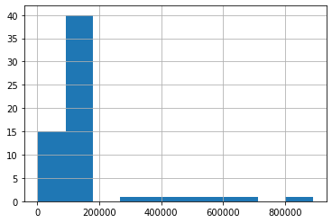

```python
# number of nulls for each column
gdd_na = gdd.apply(lambda x: x.isnull().value_counts()).T[True]

# plot a histogram of these counts
gdd_na.hist()

# https://stackoverflow.com/questions/56517295/how-to-plot-a-histogram-of-numpy-nans-in-a-pandas-dataframe
```

Investigate patterns in the amount of missing data in each column.

```python
nan_percentages = gdd.isnull().mean() * 100
nan_percentages_sorted = nan_percentages.sort_values()
print(nan_percentages_sorted)
```

```
ZABEOTYP                  0.000000
SEMIO_TRADV               0.000000
SEMIO_PFLICHT             0.000000
SEMIO_KAEM                0.000000
SEMIO_DOM                 0.000000
SEMIO_KRIT                0.000000
SEMIO_RAT                 0.000000
SEMIO_KULT                0.000000
SEMIO_ERL                 0.000000
SEMIO_LUST                0.000000
SEMIO_VERT                0.000000
SEMIO_MAT                 0.000000
SEMIO_REL                 0.000000
SEMIO_SOZ                 0.000000
SEMIO_FAM                 0.000000
FINANZ_VORSORGER          0.000000
ANREDE_KZ                 0.000000
FINANZ_MINIMALIST         0.000000
FINANZ_SPARER             0.000000
FINANZ_ANLEGER            0.000000
FINANZ_UNAUFFAELLIGER     0.000000
FINANZ_HAUSBAUER          0.000000
GREEN_AVANTGARDE          0.000000
FINANZTYP                 0.000000
ALTERSKATEGORIE_GROB      0.323264
GFK_URLAUBERTYP           0.544646
LP_STATUS_GROB            0.544646
LP_STATUS_FEIN            0.544646
ONLINE_AFFINITAET         0.544646
RETOURTYP_BK_S            0.544646
CJT_GESAMTTYP             0.544646
HH_EINKOMMEN_SCORE        2.058749
WOHNDAUER_2008            8.247000
ANZ_TITEL                 8.247000
SOHO_KZ                   8.247000
ANZ_PERSONEN              8.247000
KONSUMNAEHE               8.299737
LP_FAMILIE_GROB           8.728699
LP_FAMILIE_FEIN           8.728699
OST_WEST_KZ              10.451729
```

[output cut: 31 more lines]

```
KBA05_ANTG2              14.959701
KBA05_ANTG1              14.959701
MOBI_REGIO               14.959701
KBA05_GBZ                14.959701
KBA05_ANTG4              14.959701
W_KEIT_KIND_HH           16.605084
KKK                      17.735668
REGIOTYP                 17.735668
ALTER_HH                 34.813699
GEBURTSJAHR              44.020282
KBA05_BAUMAX             53.468668
KK_KUNDENTYP             65.596749
AGER_TYP                 76.955435
TITEL_KZ                 99.757636
dtype: float64
```

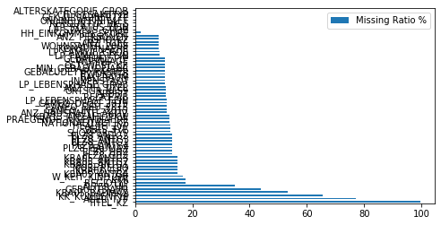

```python
def plot_nas(gdd: pd.DataFrame):
    if gdd.isnull().sum().sum() != 0:
        na_gdd = (gdd.isnull().sum() / len(gdd)) * 100
        na_gdd = na_gdd.drop(na_gdd[na_gdd == 0].index).sort_values(ascending=False)
        missing_data = pd.DataFrame({'Missing Ratio %' :na_gdd})
        missing_data.plot(kind = "barh")
        plt.show()
    else:
        print('No NAs found')
plot_nas(gdd)

plot_width, plot_height = (8,12)
plt.rcParams['figure.figsize'] = (plot_width,plot_height)

# https://stackoverflow.com/questions/69537383/how-to-plot-count-of-null-values-for-each-column-in-pandas-dataframe
```

```python
over_20_percent_nan = nan_percentages[nan_percentages > 20].index
print(over_20_percent_nan)

#In this code, nan_percentages > 20 creates a boolean mask that checks if the NaN % in each column is greater than 20%.
#Then, nan_percentages[nan_percentages > 20] filters the nan_percentages series to only include columns with more than 20% NaNs
#Finally, .index returns the column names of those columns.
```

```
Index(['AGER_TYP', 'GEBURTSJAHR', 'TITEL_KZ', 'ALTER_HH', 'KK_KUNDENTYP',
       'KBA05_BAUMAX'],
      dtype='object')
```

It looked like according to the graph (and backed up by the list of % of missing values) that the outliers are those columns in which there are more than 20% missing values - there are 6 columns:

**AGER_TYP, GEBURTSJHAR, TITEL_KZ, ALTER_HH, KK_KUNDENTYP, KBA05_BAUMAX**

I wil drop them from the dataset, so that what remains are only those columns with less than 20% of missing values.

```python
# Remove the outlier columns from the dataset.

gdd.drop(columns = over_20_percent_nan, inplace = True)
```

```python
#confirming that dropping the columns was successful
gdd.shape
```

```
(891221, 79)
```

```python
gdd.columns
```

```
Index(['ALTERSKATEGORIE_GROB', 'ANREDE_KZ', 'CJT_GESAMTTYP',
       'FINANZ_MINIMALIST', 'FINANZ_SPARER', 'FINANZ_VORSORGER',
       'FINANZ_ANLEGER', 'FINANZ_UNAUFFAELLIGER', 'FINANZ_HAUSBAUER',
       'FINANZTYP', 'GFK_URLAUBERTYP', 'GREEN_AVANTGARDE', 'HEALTH_TYP',
       'LP_LEBENSPHASE_FEIN', 'LP_LEBENSPHASE_GROB', 'LP_FAMILIE_FEIN',
       'LP_FAMILIE_GROB', 'LP_STATUS_FEIN', 'LP_STATUS_GROB',
       'NATIONALITAET_KZ', 'PRAEGENDE_JUGENDJAHRE', 'RETOURTYP_BK_S',
       'SEMIO_SOZ', 'SEMIO_FAM', 'SEMIO_REL', 'SEMIO_MAT', 'SEMIO_VERT',
       'SEMIO_LUST', 'SEMIO_ERL', 'SEMIO_KULT', 'SEMIO_RAT', 'SEMIO_KRIT',
       'SEMIO_DOM', 'SEMIO_KAEM', 'SEMIO_PFLICHT', 'SEMIO_TRADV',
       'SHOPPER_TYP', 'SOHO_KZ', 'VERS_TYP', 'ZABEOTYP', 'ANZ_PERSONEN',
       'ANZ_TITEL', 'HH_EINKOMMEN_SCORE', 'W_KEIT_KIND_HH', 'WOHNDAUER_2008',
       'ANZ_HAUSHALTE_AKTIV', 'ANZ_HH_TITEL', 'GEBAEUDETYP', 'KONSUMNAEHE',
       'MIN_GEBAEUDEJAHR', 'OST_WEST_KZ', 'WOHNLAGE', 'CAMEO_DEUG_2015',
       'CAMEO_DEU_2015', 'CAMEO_INTL_2015', 'KBA05_ANTG1', 'KBA05_ANTG2',
       'KBA05_ANTG3', 'KBA05_ANTG4', 'KBA05_GBZ', 'BALLRAUM', 'EWDICHTE',
       'INNENSTADT', 'GEBAEUDETYP_RASTER', 'KKK', 'MOBI_REGIO',
       'ONLINE_AFFINITAET', 'REGIOTYP', 'KBA13_ANZAHL_PKW', 'PLZ8_ANTG1',
       'PLZ8_ANTG2', 'PLZ8_ANTG3', 'PLZ8_ANTG4', 'PLZ8_BAUMAX', 'PLZ8_HHZ',
       'PLZ8_GBZ', 'ARBEIT', 'ORTSGR_KLS9', 'RELAT_AB'],
      dtype='object')
```

#### Discussion 1.1.2: Assess Missing Data in Each Column

Out of the 85 columns, 6 of them had a stand out proportion of missing values; that is to say over 20% values missing.

I decided to remove these columns from the dataframe as any information gleaned from them could not be considered to represent a larger portion of the surveyed population.

I checked to make sure that this was executed correctly and now we can move on to assessing missing each per row.

#### Step 1.1.3: Assess Missing Data in Each Row

Now, I will perform a similar assessment for the rows of the dataset. How much data is missing in each row? I will divide the data into two subsets: one for data points that are above some threshold for missing values, and a second subset for points below that threshold.

I received these instructions:

In order to know what to do with the outlier rows, you should see if the distribution of data values on columns that are not missing data (or are missing very little data) are similar or different between the two groups. Select at least five of these columns and compare the distribution of values.

If the distributions of non-missing features look similar between the data with many missing values and the data with few or no missing values, then we could argue that simply dropping those points from the analysis won't present a major issue. On the other hand, if the data with many missing values looks very different from the data with few or no missing values, then you should make a note on those data as special. **Either way, you should continue your analysis for now using just the subset of the data with few or no missing values.**

```python
# How much data is missing in each row of the dataset?

gdd['nan_count'] = gdd.isnull().sum(axis=1)
```

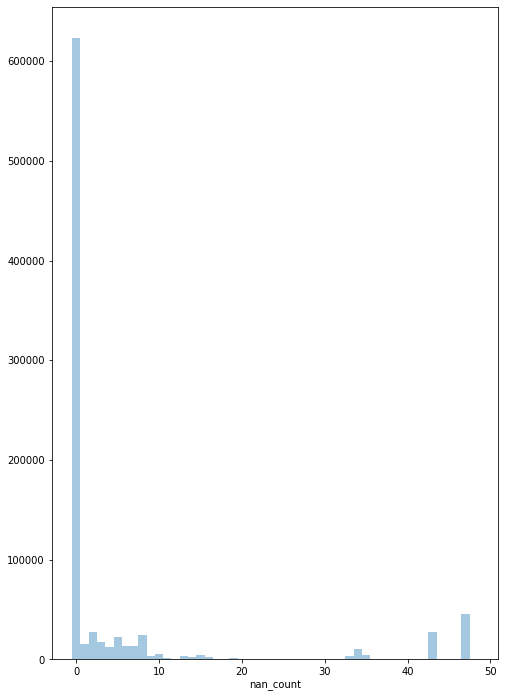

```python
sns.distplot(gdd['nan_count'],bins=np.arange(gdd['nan_count'].min(), gdd['nan_count'].max()+1),kde=False,hist_kws={"align" : "left"})
plt.show()

#https://stackoverflow.com/questions/22127769/python-frequency-of-occurrences
```

```python
# Write code to divide the data into two subsets based on the number of missing values in each row.

over_30 = gdd[gdd['nan_count'] >= 31]
under_30 = gdd[gdd['nan_count'] < 31]
```

```python
# Compare the distribution of values for at least five columns where there are
# no or few missing values, between the two subsets.

def compare_nan_datasets(name):
    plt.figure(figsize=(12,5))
    ax = plt.subplot(1,2,1)
    plt.hist(under_30[name],bins = 30)
    ax2 = plt.subplot(1,2,2)
    plt.hist(over_30[name],bins = 30, color = "green")
    plt.show()
```

NB: Blue bars = up to 30 missing values / Green bars = more than 30 missing values

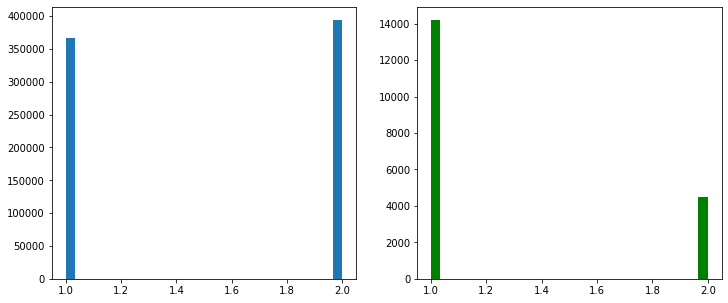

```python
compare_nan_datasets('VERS_TYP')
```

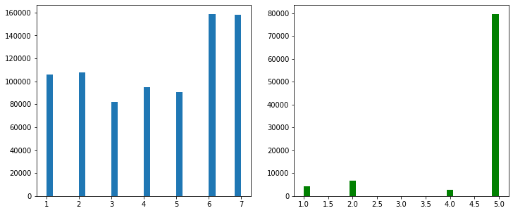

```python
compare_nan_datasets('SEMIO_LUST')
```

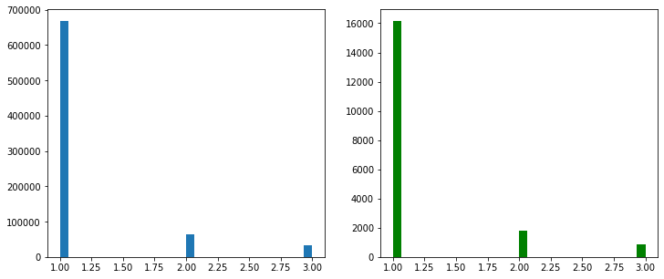

```python
compare_nan_datasets('NATIONALITAET_KZ')
```

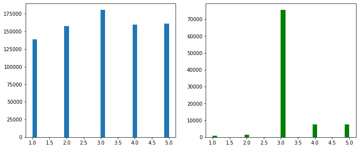

```python
compare_nan_datasets('FINANZ_MINIMALIST')
```

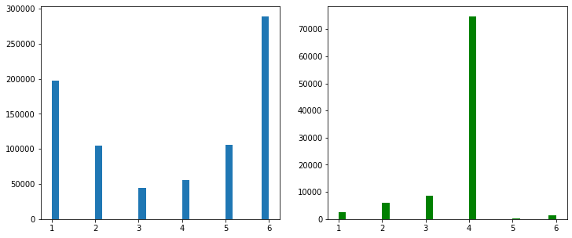

```python
compare_nan_datasets('FINANZTYP')
```

#### Discussion 1.1.3: Assess Missing Data in Each Row

From the graphs above, I can conclude that there are differences between the data with up to 30 missing values ('under_30') and the data with 31 or more missing values ('over_30'). In this way, discarding the data with above 30 missing values could mean that I miss an important inference.

However I will continue with the few missing values dataset (under_30) as instructed.

### Step 1.2: Select and Re-Encode Features

As the unsupervised learning techniques to be used will only work on data that is encoded numerically, I need to make a few encoding changes or additional assumptions to be able to make progress. While almost all of the values in the dataset are encoded using numbers, not all of them represent numeric values. See the third column of the feature summary (`feat_info`) for a summary of types of measurement.

The instructions I received are the following:

- For numeric and interval data, these features can be kept without changes.
- Most of the variables in the dataset are ordinal in nature. While ordinal values may technically be non-linear in spacing, make the simplifying assumption that the ordinal variables can be treated as being interval in nature (that is, kept without any changes).
- Special handling may be necessary for the remaining two variable types: categorical, and 'mixed'.

In the first two parts of this sub-step, I will perform an investigation of the categorical and mixed-type features and make a decision on each of them, whether to keep, drop, or re-encode each. Then, in the last part, I will create a new data frame with only the selected and engineered columns.

```python
# How many features are there of each data type in feat_info?
feat_info['type'].value_counts()
```

```
ordinal        49
categorical    21
mixed           7
numeric         7
interval        1
Name: type, dtype: int64
```

```python
#which features are of each type?
feat_info.groupby('type')['attribute'].value_counts()
```

```
type         attribute
categorical  AGER_TYP                 1
             ANREDE_KZ                1
             CAMEO_DEUG_2015          1
             CAMEO_DEU_2015           1
             CJT_GESAMTTYP            1
             FINANZTYP                1
             GEBAEUDETYP              1
             GFK_URLAUBERTYP          1
             GREEN_AVANTGARDE         1
             KK_KUNDENTYP             1
             LP_FAMILIE_FEIN          1
             LP_FAMILIE_GROB          1
             LP_STATUS_FEIN           1
             LP_STATUS_GROB           1
             NATIONALITAET_KZ         1
             OST_WEST_KZ              1
             SHOPPER_TYP              1
             SOHO_KZ                  1
             TITEL_KZ                 1
             VERS_TYP                 1
             ZABEOTYP                 1
interval     ALTER_HH                 1
mixed        CAMEO_INTL_2015          1
             KBA05_BAUMAX             1
             LP_LEBENSPHASE_FEIN      1
             LP_LEBENSPHASE_GROB      1
             PLZ8_BAUMAX              1
             PRAEGENDE_JUGENDJAHRE    1
             WOHNLAGE                 1
numeric      ANZ_HAUSHALTE_AKTIV      1
             ANZ_HH_TITEL             1
             ANZ_PERSONEN             1
             ANZ_TITEL                1
             GEBURTSJAHR              1
             KBA13_ANZAHL_PKW         1
             MIN_GEBAEUDEJAHR         1
ordinal      ALTERSKATEGORIE_GROB     1
             ARBEIT                   1
             BALLRAUM                 1
```

[output cut: 32 more lines]

```
             SEMIO_FAM                1
             SEMIO_KAEM               1
             SEMIO_KRIT               1
             SEMIO_KULT               1
             SEMIO_LUST               1
             SEMIO_MAT                1
             SEMIO_PFLICHT            1
             SEMIO_RAT                1
             SEMIO_REL                1
             SEMIO_SOZ                1
             SEMIO_TRADV              1
             SEMIO_VERT               1
             WOHNDAUER_2008           1
             W_KEIT_KIND_HH           1
Name: attribute, dtype: int64
```

#### Step 1.2.1: Re-Encode Categorical Features

For categorical data, I would ordinarily need to encode the levels as dummy variables. Depending on the number of categories, I will follow the given instructions:

- For binary (two-level) categoricals that take numeric values, keep them without needing to do anything.
- There is one binary variable that takes on non-numeric values. For this one, re-encode the values as numbers or create a dummy variable.
- For multi-level categoricals (three or more values), choose to encode the values using multiple dummy variables or (to keep things straightforward) just drop them from the analysis.

```python
# I write a for loop to create 2 lists of attributes; those that are categorial type and those that are mixed type

# define cat_name (given name in this for loop) - look at categories from feat_info.groupby(type) and the name of attribute
for cat_name, categories in feat_info.groupby('type')['attribute']:
    #if the 'type' is categorial, put the value(attribute) in a list called categorical_lst
    if cat_name == 'categorical':
        categorical_lst = categories.values.tolist()
    #repeat same process for mixed
    if cat_name == 'mixed':
        mixed_lst = categories.values.tolist()

#if the attribute name is not in the under_30 dataframe (ie. the 6 I removed), remove them from the list
for category in categorical_lst:
    if category not in under_30.columns:
        categorical_lst.remove(category)
for category in mixed_lst:
    if category not in under_30.columns:
        mixed_lst.remove(category)
```

```python
cat = under_30[categorical_lst]
cat.head()
```

|  | ANREDE_KZ | CJT_GESAMTTYP | FINANZTYP | GFK_URLAUBERTYP | GREEN_AVANTGARDE | LP_FAMILIE_FEIN | LP_FAMILIE_GROB | LP_STATUS_FEIN | LP_STATUS_GROB | NATIONALITAET_KZ | SHOPPER_TYP | SOHO_KZ | VERS_TYP | ZABEOTYP | GEBAEUDETYP | OST_WEST_KZ | CAMEO_DEUG_2015 | CAMEO_DEU_2015 |
| --- | --- | --- | --- | --- | --- | --- | --- | --- | --- | --- | --- | --- | --- | --- | --- | --- | --- | --- |
| 1 | 2 | 5.0 | 1 | 10.0 | 0 | 5.0 | 3.0 | 2.0 | 1.0 | 1.0 | 3.0 | 1.0 | 2.0 | 5 | 8.0 | W | 8 | 8A |
| 2 | 2 | 3.0 | 1 | 10.0 | 1 | 1.0 | 1.0 | 3.0 | 2.0 | 1.0 | 2.0 | 0.0 | 1.0 | 5 | 1.0 | W | 4 | 4C |
| 3 | 2 | 2.0 | 6 | 1.0 | 0 | NaN | NaN | 9.0 | 4.0 | 1.0 | 1.0 | 0.0 | 1.0 | 3 | 1.0 | W | 2 | 2A |
| 4 | 1 | 5.0 | 5 | 5.0 | 0 | 10.0 | 5.0 | 3.0 | 2.0 | 1.0 | 2.0 | 0.0 | 2.0 | 4 | 1.0 | W | 6 | 6B |
| 5 | 2 | 2.0 | 2 | 1.0 | 0 | 1.0 | 1.0 | 4.0 | 2.0 | 1.0 | 0.0 | 0.0 | 2.0 | 4 | 1.0 | W | 8 | 8C |

```python
# create lists of binary and multilevel categorical attributes - those with 2 unique values as responses (binary) and
# those with more than 2 responses (multi)
binary_lst = []
multilevel_lst = []

for category, nunique in cat.nunique().iteritems():
    if nunique == 2:
        binary_lst.append(category)
    else:
        multilevel_lst.append(category)
```

```python
# show the categories in the binary list
under_30[binary_lst].head()
```

|  | ANREDE_KZ | GREEN_AVANTGARDE | SOHO_KZ | VERS_TYP | OST_WEST_KZ |
| --- | --- | --- | --- | --- | --- |
| 1 | 2 | 0 | 1.0 | 2.0 | W |
| 2 | 2 | 1 | 0.0 | 1.0 | W |
| 3 | 2 | 0 | 0.0 | 1.0 | W |
| 4 | 1 | 0 | 0.0 | 2.0 | W |
| 5 | 2 | 0 | 0.0 | 2.0 | W |

#### Discussion 1.2.1: Re-Encode Categorical Features

Two-level binary variables are: ANREDE_KZ, SOHO_KZ, OST_WEST_KZ, VERS_TYP and GREEN_AVANTGARDE

The binary variable which uses letters and numbers is OST_WEST_KZ. I will change this to numerical values.

The rest of the variables are multi-level variables and therefore will be encoded. I chose not to drop these variables as they may tell us something important about the customer and their behaviour.

```python
# OST_WEST-KZ has letters in the results.
# Check out what the responses are and replace that with 1 and 0 to be able to feed models later.
under_30["OST_WEST_KZ"].value_counts()
```

```
W    629525
O    168542
Name: OST_WEST_KZ, dtype: int64
```

```python
under_30.replace({'OST_WEST_KZ':{'W':0, 'O': 1}}, inplace = True)
```

```python
#Check if it worked
under_30["OST_WEST_KZ"].value_counts()
```

```
0    629525
1    168542
Name: OST_WEST_KZ, dtype: int64
```

Check the other binary variables

```python
under_30["ANREDE_KZ"].value_counts()
```

```
2    416181
1    381886
Name: ANREDE_KZ, dtype: int64
```

```python
under_30["GREEN_AVANTGARDE"].value_counts()
```

```
0    622842
1    175225
Name: GREEN_AVANTGARDE, dtype: int64
```

```python
under_30["SOHO_KZ"].value_counts()
```

```
0.0    791350
1.0      6717
Name: SOHO_KZ, dtype: int64
```

```python
#Andrede_KZ also needs to be changed into 0 and 1
under_30.replace({'ANREDE_KZ':{2:0}}, inplace = True)
```

```python
#Check if it worked
under_30["ANREDE_KZ"].value_counts()

#NB: The 2 turned into 0 and the 1 stayed as 1
```

```
0    416181
1    381886
Name: ANREDE_KZ, dtype: int64
```

```python
#VERS_TYP also needs to be changed into 0 and 1
under_30.replace({'VERS_TYP':{2:0}}, inplace = True)
```

```python
#Check if it worked
under_30["VERS_TYP"].value_counts()

#NB: Social-safety driven stays as 1, individualistic becomes 0
```

```
0.0    394238
1.0    367103
Name: VERS_TYP, dtype: int64
```

```python
# show the categories in the multilevel list
under_30[multilevel_lst].head()
```

|  | CJT_GESAMTTYP | FINANZTYP | GFK_URLAUBERTYP | LP_FAMILIE_FEIN | LP_FAMILIE_GROB | LP_STATUS_FEIN | LP_STATUS_GROB | NATIONALITAET_KZ | SHOPPER_TYP | ZABEOTYP | GEBAEUDETYP | CAMEO_DEUG_2015 | CAMEO_DEU_2015 |
| --- | --- | --- | --- | --- | --- | --- | --- | --- | --- | --- | --- | --- | --- |
| 1 | 5.0 | 1 | 10.0 | 5.0 | 3.0 | 2.0 | 1.0 | 1.0 | 3.0 | 5 | 8.0 | 8 | 8A |
| 2 | 3.0 | 1 | 10.0 | 1.0 | 1.0 | 3.0 | 2.0 | 1.0 | 2.0 | 5 | 1.0 | 4 | 4C |
| 3 | 2.0 | 6 | 1.0 | NaN | NaN | 9.0 | 4.0 | 1.0 | 1.0 | 3 | 1.0 | 2 | 2A |
| 4 | 5.0 | 5 | 5.0 | 10.0 | 5.0 | 3.0 | 2.0 | 1.0 | 2.0 | 4 | 1.0 | 6 | 6B |
| 5 | 2.0 | 2 | 1.0 | 1.0 | 1.0 | 4.0 | 2.0 | 1.0 | 0.0 | 4 | 1.0 | 8 | 8C |

Onehotencode the multi-level variables

```python
under_30 = pd.get_dummies(under_30, columns=multilevel_lst)
```

```python
# check to see that it worked
under_30.head()
```

|  | ALTERSKATEGORIE_GROB | ANREDE_KZ | FINANZ_MINIMALIST | FINANZ_SPARER | FINANZ_VORSORGER | FINANZ_ANLEGER | FINANZ_UNAUFFAELLIGER | FINANZ_HAUSBAUER | GREEN_AVANTGARDE | HEALTH_TYP | LP_LEBENSPHASE_FEIN | LP_LEBENSPHASE_GROB | PRAEGENDE_JUGENDJAHRE | RETOURTYP_BK_S | SEMIO_SOZ | SEMIO_FAM | SEMIO_REL | SEMIO_MAT | SEMIO_VERT | SEMIO_LUST | SEMIO_ERL | SEMIO_KULT | SEMIO_RAT | SEMIO_KRIT | SEMIO_DOM | SEMIO_KAEM | SEMIO_PFLICHT | SEMIO_TRADV | SOHO_KZ | … |
| --- | --- | --- | --- | --- | --- | --- | --- | --- | --- | --- | --- | --- | --- | --- | --- | --- | --- | --- | --- | --- | --- | --- | --- | --- | --- | --- | --- | --- | --- | --- |
| 1 | 1.0 | 0 | 1 | 5 | 2 | 5 | 4 | 5 | 0 | 3.0 | 21.0 | 6.0 | 14.0 | 1.0 | 5 | 4 | 4 | 3 | 1 | 2 | 2 | 3 | 6 | 4 | 7 | 4 | 7 | 6 | 1.0 | … |
| 2 | 3.0 | 0 | 1 | 4 | 1 | 2 | 3 | 5 | 1 | 3.0 | 3.0 | 1.0 | 15.0 | 3.0 | 4 | 1 | 3 | 3 | 4 | 4 | 6 | 3 | 4 | 7 | 7 | 7 | 3 | 3 | 0.0 | … |
| 3 | 4.0 | 0 | 4 | 2 | 5 | 2 | 1 | 2 | 0 | 2.0 | NaN | NaN | 8.0 | 2.0 | 5 | 1 | 2 | 1 | 4 | 4 | 7 | 4 | 3 | 4 | 4 | 5 | 4 | 4 | 0.0 | … |
| 4 | 3.0 | 1 | 4 | 3 | 4 | 1 | 3 | 2 | 0 | 3.0 | 32.0 | 10.0 | 8.0 | 5.0 | 6 | 4 | 4 | 2 | 7 | 4 | 4 | 6 | 2 | 3 | 2 | 2 | 4 | 2 | 0.0 | … |
| 5 | 1.0 | 0 | 3 | 1 | 5 | 2 | 2 | 5 | 0 | 3.0 | 8.0 | 2.0 | 3.0 | 3.0 | 2 | 4 | 7 | 4 | 2 | 2 | 2 | 5 | 7 | 4 | 4 | 4 | 7 | 6 | 0.0 | … |

#### Step 1.2.2: Engineer Mixed-Type Features

There are a handful of features that are marked as "mixed" in the feature summary that require special treatment in order to be included in the analysis. There are two in particular for which I was given instructions:

- "PRAEGENDE_JUGENDJAHRE" combines information on three dimensions: generation by decade, movement (mainstream vs. avantgarde), and nation (east vs. west). While there aren't enough levels to disentangle east from west, you should create two new variables to capture the other two dimensions: an interval-type variable for decade, and a binary variable for movement.
- "CAMEO_INTL_2015" combines information on two axes: wealth and life stage. Break up the two-digit codes by their 'tens'-place and 'ones'-place digits into two new ordinal variables (which, for the purposes of this project, is equivalent to just treating them as their raw numeric values).

```python
mixed = under_30[mixed_lst]
mixed.head()
```

|  | LP_LEBENSPHASE_FEIN | LP_LEBENSPHASE_GROB | PRAEGENDE_JUGENDJAHRE | WOHNLAGE | CAMEO_INTL_2015 | PLZ8_BAUMAX |
| --- | --- | --- | --- | --- | --- | --- |
| 1 | 21.0 | 6.0 | 14.0 | 4.0 | 51 | 1.0 |
| 2 | 3.0 | 1.0 | 15.0 | 2.0 | 24 | 1.0 |
| 3 | NaN | NaN | 8.0 | 7.0 | 12 | 1.0 |
| 4 | 32.0 | 10.0 | 8.0 | 3.0 | 43 | 2.0 |
| 5 | 8.0 | 2.0 | 3.0 | 7.0 | 54 | 1.0 |

Investigate "CAMEO_INTL_2015" and engineer two new variables.

CAMEO_INTL_2015 entries have two digits.

The first digit represents wealth (from 1-5) and the second digit represents life stage (1-5)

CAMEO_INTL_2015 has NaNs. I will be sure to include instruction on how to treat them.

```python
# Wealth
# create a function open with def, wealth is the function name and it will be applied to values
def wealth(value):
    # In case value is NaN
    if pd.isnull(value):
        return np.nan
    else:
        # Return first digit
        return int(str(value)[0])

# Life stage
# create a function open with def, life_stage is the function name and it will be applied to values
def life_stage(value):
    # In case value is NaN
    if pd.isnull(value):
        return np.nan
    else:
        # Return second digit
        return int(str(value)[1])
```

```python
# Create wealth column by applying the wealth function to under_30 using .apply
under_30['CAMEO_INTL_2015_WEALTH'] = under_30['CAMEO_INTL_2015'].apply(wealth)

# Create life stage column
under_30['CAMEO_INTL_2015_LIFESTAGE'] = under_30['CAMEO_INTL_2015'].apply(life_stage)
```

```python
# drop the original column
under_30.drop(['CAMEO_INTL_2015'], axis = 1, inplace=True)
```

Investigate "PRAEGENDE_JUGENDJAHRE" and engineer two new variables.

Several possible entries can stand for the same decade. I will group each of those to create one number for each decade.

For movement there are only two possible choices: mainstream or avantgarde - this can be binary.

```python
# Generation
# create a dictionary with 0-5 as the key and the possible entried pertaining to decades as the values
generations = {0: [1, 2], # 40s
               1: [3, 4], # 50s
               2: [5, 6, 7], # 60s
               3: [8, 9], # 70s
               4: [10, 11, 12, 13], # 80s
               5:[14, 15]} # 90s

# create a function open with def, generation is the function name and it will be applied to values
def generation(value):
    try:
        #for loop: for each key, you can find the corresponding values in the generations.items
        for key, values in generations.items():
            #if the value being searched can be seen in the list of values in generations dict, return the key
            if value in values:
                return key
    # In case value is NaN
    except ValueError:
        return np.nan

# Movement
# create list of possible responses that represent mainstream
mainstream = [1, 3, 5, 8, 10, 12, 14]

def movement(value):
    try:
        if value in mainstream:
            return 1
        else:
            return 0
    # In case value is NaN
    except ValueError:
        return np.nan
```

```python
# Create generation column
under_30['PRAEGENDE_JUGENDJAHRE_GEN'] = under_30['PRAEGENDE_JUGENDJAHRE'].apply(generation)

# Create movement column
under_30['PRAEGENDE_JUGENDJAHRE_MOV'] = under_30['PRAEGENDE_JUGENDJAHRE'].apply(movement)
```

```python
# drop the original column
under_30.drop(['PRAEGENDE_JUGENDJAHRE'], axis = 1, inplace=True)
```

```python
# Remove unneeded mixed columns
under_30.drop(['PLZ8_BAUMAX',
                'LP_LEBENSPHASE_GROB',
                'LP_LEBENSPHASE_FEIN',
                'WOHNLAGE'], axis=1, inplace=True)
```

#### Discussion 1.2.2: Engineer Mixed-Type Features

Firstly I treated the suggested mixed variables of CAMEO_INTL_2015 and PRAEGENDE_JUGENDJAHRE.

With CAMEO_INTL_2015 it was a simple matter of splitting the two digits, which already had assigned significance in the dictionary. I gave them new column names and then deleted the original column.

For PRAEGENDE_JUGENDJAHRE, as several responses belonged to the same decade, I assigned a grouping number for each decade and then assigned a 1 or 0 to mainstream or not mainstream (by default, avantgarde). I gave them new column names and then deleted the original column.

For the other mixed variables, I looked them up in the dictionary for the definitions.

I concluded that none of the other mixed type variables were useful to keep.

LP_LEBENSPHASE_FEIN is simply a more detailed version of LP_LEBENSPAHSE_GROS, so deleting it would only cause us to loose some level of granularity.LP_LEBENSPAHSE_GROS is also not needed, because we just created a 'life_stage' column in the above engineering.

Wohnlage is a categorisation of neighbourhood quality. However we have no understanding of how this categorising is done, so the data loses relevance.

Finally PLZ8_BAUMAX refers to the most common building type within PL28 (which I assume is an area). This data is very specific and I don't believe it would contribute a great deal to the overall picture which is at country level.

Therefore, I dropped those columns as well.

#### Step 1.2.3: Complete Feature Selection

In order to finish this step, I need to make sure that my data frame now only has the columns that I want to keep.

To summarise, the dataframe should consist of the following:

- All numeric, interval, and ordinal type columns from the original dataset.
- Binary categorical features (all numerically-encoded).
- Engineered features from other multi-level categorical features and mixed features.

These are the columns that should be passed to the algorithm functions.

```python
under_30.head().T
```

|  | 1 | 2 | 3 | 4 | 5 |
| --- | --- | --- | --- | --- | --- |
| ALTERSKATEGORIE_GROB | 1.0 | 3.0 | 4.0 | 3.0 | 1.0 |
| ANREDE_KZ | 0.0 | 0.0 | 0.0 | 1.0 | 0.0 |
| FINANZ_MINIMALIST | 1.0 | 1.0 | 4.0 | 4.0 | 3.0 |
| FINANZ_SPARER | 5.0 | 4.0 | 2.0 | 3.0 | 1.0 |
| FINANZ_VORSORGER | 2.0 | 1.0 | 5.0 | 4.0 | 5.0 |
| FINANZ_ANLEGER | 5.0 | 2.0 | 2.0 | 1.0 | 2.0 |
| FINANZ_UNAUFFAELLIGER | 4.0 | 3.0 | 1.0 | 3.0 | 2.0 |
| FINANZ_HAUSBAUER | 5.0 | 5.0 | 2.0 | 2.0 | 5.0 |
| GREEN_AVANTGARDE | 0.0 | 1.0 | 0.0 | 0.0 | 0.0 |
| HEALTH_TYP | 3.0 | 3.0 | 2.0 | 3.0 | 3.0 |
| RETOURTYP_BK_S | 1.0 | 3.0 | 2.0 | 5.0 | 3.0 |
| SEMIO_SOZ | 5.0 | 4.0 | 5.0 | 6.0 | 2.0 |
| SEMIO_FAM | 4.0 | 1.0 | 1.0 | 4.0 | 4.0 |
| SEMIO_REL | 4.0 | 3.0 | 2.0 | 4.0 | 7.0 |
| SEMIO_MAT | 3.0 | 3.0 | 1.0 | 2.0 | 4.0 |
| SEMIO_VERT | 1.0 | 4.0 | 4.0 | 7.0 | 2.0 |
| SEMIO_LUST | 2.0 | 4.0 | 4.0 | 4.0 | 2.0 |
| SEMIO_ERL | 2.0 | 6.0 | 7.0 | 4.0 | 2.0 |
| SEMIO_KULT | 3.0 | 3.0 | 4.0 | 6.0 | 5.0 |
| SEMIO_RAT | 6.0 | 4.0 | 3.0 | 2.0 | 7.0 |
| SEMIO_KRIT | 4.0 | 7.0 | 4.0 | 3.0 | 4.0 |
| SEMIO_DOM | 7.0 | 7.0 | 4.0 | 2.0 | 4.0 |
| SEMIO_KAEM | 4.0 | 7.0 | 5.0 | 2.0 | 4.0 |
| SEMIO_PFLICHT | 7.0 | 3.0 | 4.0 | 4.0 | 7.0 |
| SEMIO_TRADV | 6.0 | 3.0 | 4.0 | 2.0 | 6.0 |
| SOHO_KZ | 1.0 | 0.0 | 0.0 | 0.0 | 0.0 |
| VERS_TYP | 0.0 | 1.0 | 1.0 | 0.0 | 0.0 |
| ANZ_PERSONEN | 2.0 | 1.0 | 0.0 | 4.0 | 1.0 |
| ANZ_TITEL | 0.0 | 0.0 | 0.0 | 0.0 | 0.0 |
| HH_EINKOMMEN_SCORE | 6.0 | 4.0 | 1.0 | 5.0 | 5.0 |

[output cut: 163 more lines]

```python
# drop the nan_count column
under_30.drop(['nan_count'], axis = 1, inplace=True)
```

```python
under_30.shape
```

```
(798067, 192)
```

### Step 1.3: Create a Cleaning Function

Even though I've finished cleaning up the general population demographics data, it's important to look ahead to the future and realize that I will need to perform the same cleaning steps on the customer demographics data. Therefore, I will write a function to execute the main feature selection, encoding, and re-engineering steps performed above.

Then, when it comes to looking at the customer data in Step 3, I can simply run this function on that DataFrame to get the trimmed dataset in a single step.

```python
def clean_data(df):
    """
    Perform feature trimming, re-encoding, and engineering for demographics
    data

    INPUT: Demographics DataFrame
    OUTPUT: Trimmed and cleaned demographics DataFrame
    """
#treat encoded missing or unknown values

    #create a list from the attribute name and the corresponding missing values codes from feat_info dataframe using zip
    #start a for loop which will, for each attribute and missing_or_unknown pair, strip '[]' and split by ',' and store in
    #missing_values

    for attribute, missing_or_unknown in zip(feat_info['attribute'], feat_info['missing_or_unknown']):
        missing_values = missing_or_unknown.strip('[]').split(',')

        #if missing or unknown code is an integer, convert to int type. Otherwise leave as-is, including blanks
        missing_values = [int(value) if (value!='X' and value!='XX' and value!='') else value for value in missing_values]
        if missing_values != ['']:

            if attribute in df.columns:

                #for the attribute within gdd, look for any missing_values identified above and replace with nan
                df[attribute] = df[attribute].replace(missing_values, np.nan)

# remove selected columns and rows, ...

    #remove selected columns

    df.drop(columns=['AGER_TYP', 'GEBURTSJAHR', 'TITEL_KZ', 'ALTER_HH', 'KK_KUNDENTYP',
       'KBA05_BAUMAX'], inplace=True)

    #remove selected rows
    #create a column called nan_count that can be used to split the dataframe in two
    df['nan_count'] = df.isnull().sum(axis=1)

    # Write code to divide the data into two subsets based on the number of missing values in each row.
    over_30_cust = df[df['nan_count'] >= 31].copy()
    under_30_cust = df[df['nan_count'] < 31].copy()

# select, re-encode, and engineer column values.

    # Select categorical features names
    # A for loop to create 2 lists of attributes; those that are categorial type and those that are mixed type
    for cat_name, categories in feat_info.groupby('type')['attribute']:
        if cat_name == 'categorical':
            categorical_lst = categories.values.tolist()
        if cat_name == 'mixed':
            mixed_lst = categories.values.tolist()

    #if the columns/attributes have been deleted in previous steps, remove them from the list
    categorical_lst_clean = []
    mixed_lst_clean = []

    for category in categorical_lst:
        if category in under_30_cust.columns:
            categorical_lst_clean.append(category)
    for category in mixed_lst:
        if category in under_30_cust.columns:
            mixed_lst_clean.append(category)

     #create for loop to separate categorical attributes into binary categories (2 responses) and multi-level
    binary_lst = []
    multilevel_lst = []

    for category, nunique in under_30_cust[categorical_lst_clean].nunique().iteritems():
        if nunique == 2:
            binary_lst.append(category)
        else:
            multilevel_lst.append(category)

    # Standardise binary columns into 0 or 1
    if 'OST_WEST_KZ' in under_30_cust:
        under_30_cust['OST_WEST_KZ'].replace(['W', 'O'], [1, 0], inplace=True)
    if 'ANREDE_KZ' in under_30_cust:
        under_30_cust['ANREDE_KZ'].replace([2], [0], inplace=True)
    if 'VERS_TYP' in under_30_cust:
        under_30_cust['VERS_TYP'].replace([2.0], [0], inplace=True)

    # Do one-hot-encoding and remove reference columns
    under_30_cust = pd.get_dummies(under_30_cust, columns=multilevel_lst)

    #"GEBAEUDETYP_5.0" doesn't appear in the customer data frame, because there were no '5' responses in the data
    #If we pass it to the one hot encoder, we end up with a different number of columns between the datasets
    #Here we create a column in the customer dataset called "GEBAEUDETYP_5.0" and fill it with 0's as a workaround

    if 'GEBAEUDETYP_5.0' not in under_30_cust.columns:
        under_30_cust['GEBAEUDETYP_5.0']=0

# Engineer features

    # create new columns by applying previously written functions to an attribute, splitting it into two categories
    if 'PRAEGENDE_JUGENDJAHRE' in under_30_cust:
        under_30_cust['PRAEGENDE_JUGENDJAHRE_GEN'] = under_30_cust['PRAEGENDE_JUGENDJAHRE'].apply(generation)
    if 'PRAEGENDE_JUGENDJAHRE' in under_30_cust:
        under_30_cust['PRAEGENDE_JUGENDJAHRE_MOV'] = under_30_cust['PRAEGENDE_JUGENDJAHRE'].apply(movement)
    if 'CAMEO_INTL_2015' in under_30_cust:
        under_30_cust['CAMEO_INTL_2015_WEALTH'] = under_30_cust['CAMEO_INTL_2015'].apply(wealth)
    if 'CAMEO_INTL_2015' in under_30_cust:
        under_30_cust['CAMEO_INTL_2015_LIFESTAGE'] = under_30_cust['CAMEO_INTL_2015'].apply(life_stage)

    # Remove unneeded mixed columns (the engineered columns and the ones I decided to drop)
    column_to_drop =['PRAEGENDE_JUGENDJAHRE',
                          'CAMEO_INTL_2015',
                          'PLZ8_BAUMAX',
                          'LP_LEBENSPHASE_FEIN',
                          'LP_LEBENSPHASE_GROB',
                          'WOHNLAGE',
                          'nan_count']
    col_to_drop = []
    for c in column_to_drop:
        if c in under_30_cust.columns:
            col_to_drop.append(c)
    clean_under_30_cust = under_30_cust.drop(col_to_drop, axis=1)

    #valid_col_to_drop = []
    #for column_name in column_to_drop:
        #if column_name in under_30_cust.columns:
            #valid_col_to_drop.append(column_name)
    #clean_under_30_cust = under_30_cust.drop(valid_col_to_drop, axis=1)

# Return the cleaned dataframe.
    return clean_under_30_cust
```

## Step 2: Feature Transformation

### Step 2.1: Apply Feature Scaling

Before I apply dimensionality reduction techniques to the data, I need to perform feature scaling so that the principal component vectors are not influenced by the natural differences in scale for features.

In this substep, I check the following:

- sklearn requires that data not have missing values in order for its estimators to work properly. So, before applying the scaler to the data, make sure that the DataFrame has been cleaned of the remaining missing values. This can be as simple as just removing all data points with missing data, or applying an [Imputer](https://scikit-learn.org/0.16/modules/generated/sklearn.preprocessing.Imputer.html) to replace all missing values.
- For the actual scaling function, a [StandardScaler](http://scikit-learn.org/stable/modules/generated/sklearn.preprocessing.StandardScaler.html) instance is suggested, scaling each feature to mean 0 and standard deviation 1.
- For these classes, I made use of the `.fit_transform()` method to both fit a procedure to the data as well as apply the transformation to the data at the same time.

I will check to see that the dataset has been cleaned all NaN values

```python
# How many nans are left?

num_obvs = under_30.shape[0]*under_30.shape[1]
print(num_obvs)
```

```
153228864
```

```python
num_nans = under_30.isna().sum().sum()
print(num_nans)
```

```
734627
```

```python
'{:.1%}'.format(num_nans/num_obvs)
```

```
'0.5%'
```

```python
under_30_columns = under_30.keys().tolist()
```

I will apply the imputer to replace all missing values

```python
#Impute the data using a simple imputer - most frequent, because not all values are numerical

from sklearn.impute import SimpleImputer
impute_most_frequent_all = SimpleImputer(strategy='most_frequent')
clean_under_30 = impute_most_frequent_all.fit_transform(under_30)

# When axis=0, columns which only contained missing values at fit are discarded upon transform.
```

Now I apply the standard scaler, scaling each feature to mean 0 and standard deviation 1

```python
# Apply feature scaling to the general population demographics data.
# Standardscaler imported in cell 1

# Standardising
scaler = StandardScaler()
clean_under_30 = scaler.fit_transform(clean_under_30)

#https://www.digitalocean.com/community/tutorials/standardscaler-function-in-python
```

### Discussion 2.1: Apply Feature Scaling

All features in the dataset, after removing the 'over_20_percent_nan' columns have, as the name suggested, less than 20% nans. Further, as I am now working with the dataset '30_or_under', each row has 30 or less nans in it.

Dropping nan only makes sense when there is a feature with a very high value of nans, because it won't tell you much about your subject.

As all columns here have a reasonable amount of data, it made more sense to impute them.

### Step 2.2: Perform Dimensionality Reduction

Now that I have scaled data, it is now ready to apply dimensionality reduction techniques. These techniques take the full data set and reduce it to only the parts that hold the most information.

I received the following instructions:

- Use sklearn's [PCA](http://scikit-learn.org/stable/modules/generated/sklearn.decomposition.PCA.html) class to apply principal component analysis on the data, thus finding the vectors of maximal variance in the data. To start, you should not set any parameters (so all components are computed) or set a number of components that is at least half the number of features (so there's enough features to see the general trend in variability).
- Check out the ratio of variance explained by each principal component as well as the cumulative variance explained. Try plotting the cumulative or sequential values using matplotlib's [`plot()`](https://matplotlib.org/api/_as_gen/matplotlib.pyplot.plot.html) function. Based on what you find, select a value for the number of transformed features you'll retain for the clustering part of the project.
- Once you've made a choice for the number of components to keep, make sure you re-fit a PCA instance to perform the decided-on transformation.

#### What does PCA do?

Principal component analysis, or PCA, is a dimensionality reduction method that is often used to reduce the dimensionality of large data sets, by transforming a large set of variables into a smaller one that still contains most of the information in the large set.

Reducing the number of variables of a data set naturally comes at the expense of accuracy, but the trick in dimensionality reduction is to trade a little accuracy for simplicity. Smaller data sets are easier to explore and visualize and make analyzing data points much easier and faster for machine learning algorithms without extraneous variables to process.

PCA is often used to speed up the fitting of machine learning algorithms. It can also be used for data visualisation.

Data must be standardised first (done in previous step).

```python
clean_under_30.shape
```

```
(798067, 192)
```

```python
# Apply PCA to the data.
# Number of components I will try is half the current number

n_components = clean_under_30.shape[1] // 2
pca = PCA(n_components=n_components)
pca = pca.fit(clean_under_30)
```

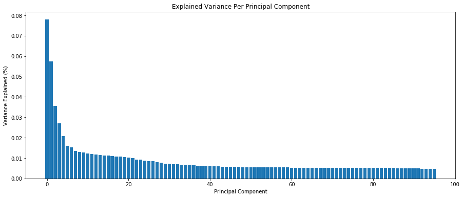

```python
# Investigate the variance accounted for by each principal component.

components = np.arange(n_components)
exp_variance = pca.explained_variance_ratio_
plt.figure(figsize=(15, 6))
plt.bar(components, exp_variance)
plt.xlabel("Principal Component")
plt.ylabel("Variance Explained (%)")
plt.title("Explained Variance Per Principal Component");
```

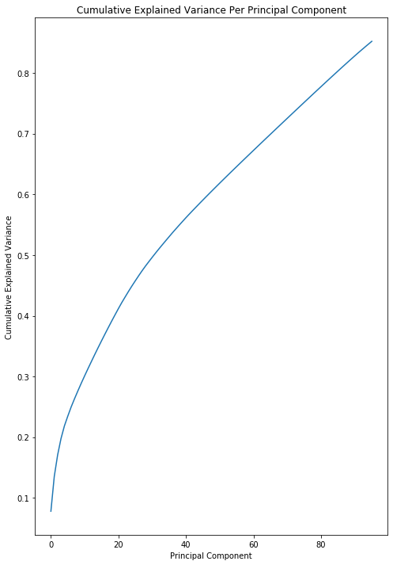

```python
# plot the scree plot

cum_vals = np.cumsum(exp_variance)
plt.plot(components, cum_vals)
plt.xlabel("Principal Component")
plt.ylabel("Cumulative Explained Variance")
plt.title("Cumulative Explained Variance Per Principal Component");
```

```python
print('Cumulative Explained Variance:', pca.explained_variance_ratio_.sum())
```

```
Cumulative Explained Variance: 0.8522650923007361
```

```python
# Re-apply PCA to the data while selecting for number of components to retain.

clean_under_30_pca = pca.transform(clean_under_30)
```

```python
clean_under_30_pca.shape
```

```
(798067, 96)
```

### Discussion 2.2: Perform Dimensionality Reduction

My first try was to divide the number of components by half. After finding that this will explain 85% of the data, I decided to stick with this for simplicity, although I could have run a loop to try and get a higher score, 85% is acceptable.

### Step 2.3: Interpret Principal Components

Now that that data has transformed principal components, I will check out the weight of each variable on the first few components to see if they can be interpreted in some fashion.

As a reminder, each principal component is a unit vector that points in the direction of highest variance (after accounting for the variance captured by earlier principal components). The further a weight is from zero, the more the principal component is in the direction of the corresponding feature.

If two features have large weights of the same sign (both positive or both negative), then increases in one tend expect to be associated with increases in the other. To contrast, features with different signs can be expected to show a negative correlation: increases in one variable should result in a decrease in the other.

I recieved these instructions:

- To investigate the features, you should map each weight to their corresponding feature name, then sort the features according to weight. The most interesting features for each principal component, then, will be those at the beginning and end of the sorted list. Use the data dictionary document to help you understand these most prominent features, their relationships, and what a positive or negative value on the principal component might indicate.
- You should investigate and interpret feature associations from the first three principal components in this substep. To help facilitate this, you should write a function that you can call at any time to print the sorted list of feature weights, for the *i*-th principal component. This might come in handy in the next step of the project, when you interpret the tendencies of the discovered clusters.

```python
# Define a function here that you can reuse in the other cell
# https://www.linkedin.com/pulse/how-interpret-principal-component-analysis-ali-mirzaei/

def map_comp_weight(df, pca, component):
    """
    input:
        df - Dataframe
        pca - Fitted PCA instance
        component - Index of the component

    return:
        dataframe: Mapping of features to their weights in the component
    """
    component_weight = pd.DataFrame(pca.components_, columns = under_30_columns).iloc[component]
    component_weight.sort_values(ascending=False, inplace=True)

    return component_weight

# The above function has created a dataframe with the components of the pca result
```

```python
def plot_comp_weight(df, pca, component, feature_plot):
    component_weight = map_comp_weight(df, pca, component)
    component_weight = pd.concat([component_weight.head(feature_plot), component_weight.tail(feature_plot)])

    component_weight.plot(kind='bar')
    plt.title('Component {}'.format(component))
    plt.ylabel('Weight')
    ax = plt.gca()
    ax.grid(linewidth='0.4', alpha=0.4)
    ax.set_axisbelow(True)
    plt.show()

    return component_weight
```

```python
component_weight = plot_comp_weight(clean_under_30_pca, pca, 0, 5)
component_weight
```

```
LP_STATUS_GROB_1.0        0.197467
HH_EINKOMMEN_SCORE        0.186070
CAMEO_INTL_2015_WEALTH    0.185030
PLZ8_ANTG3                0.182028
PLZ8_ANTG4                0.175643
KBA05_ANTG1              -0.180883
KBA05_GBZ                -0.181540
PLZ8_ANTG1               -0.183152
MOBI_REGIO               -0.188299
FINANZ_MINIMALIST        -0.195395
Name: 0, dtype: float64
```

### Discussion: Component 0

#### Postive weights are:

LP_STATUS_GROB_1.0 0.195735 - Social status (low income earners, homeowners etc.)

HH_EINKOMMEN_SCORE 0.185745 - Estimated household net income

CAMEO_INTL_2015_WEALTH 0.183597 - Wealth (how wealthy is the household, 5 categories from wealthy to poor)

PLZ8_ANTG3 0.180211 - Number of 6-10 family houses in the PLZ8 region

PLZ8_ANTG4 0.173751 - Number of 10+ family houses in the PLZ8 region

#### Negative weights are:

KBA05_ANTG1 -0.179658 - Number of 1-2 family houses in the microcell

KBA05_GBZ -0.180202 - Number of buildings in the microcell

PLZ8_ANTG1 -0.181378 - Number of 1-2 family houses in the PLZ8 region

MOBI_REGIO -0.187004 - Movement patterns

FINANZ_MINIMALIST -0.192677 - MINIMALIST: low financial interest

It looks like component 0 is concerned with wealth, social status and size of houses.

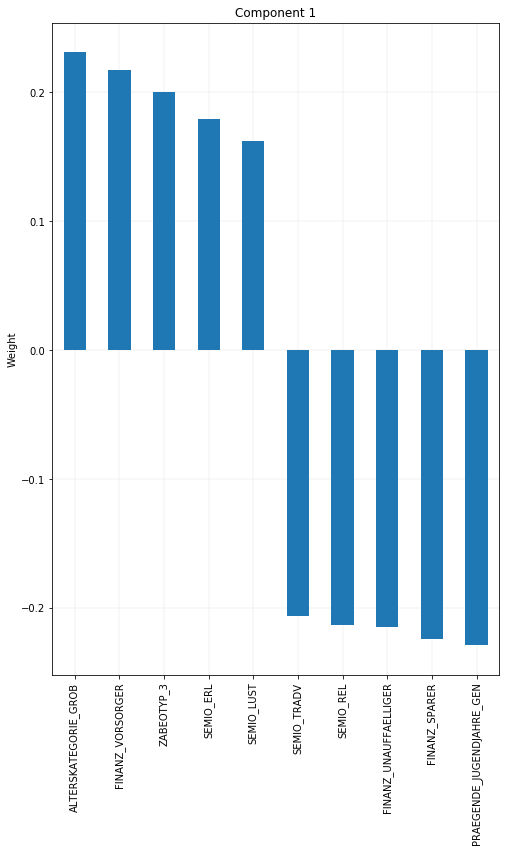

```
ALTERSKATEGORIE_GROB         0.230935
FINANZ_VORSORGER             0.216951
ZABEOTYP_3                   0.200141
SEMIO_ERL                    0.179391
SEMIO_LUST                   0.161768
SEMIO_TRADV                 -0.206383
SEMIO_REL                   -0.213444
FINANZ_UNAUFFAELLIGER       -0.214702
FINANZ_SPARER               -0.224339
PRAEGENDE_JUGENDJAHRE_GEN   -0.228997
Name: 1, dtype: float64
```

```python
# Map weights for the second principal component to corresponding feature names
# and then print the linked values, sorted by weight.

component_weight = plot_comp_weight(clean_under_30_pca, pca, 1, 5)
component_weight
```

## Discussion: Component 1

#### Postive weights are:

ALTERSKATEGORIE_GROB 0.232507 - Estimated age

FINANZ_VORSORGER 0.218410 - Finance type 'be prepared'

ZABEOTYP_3 0.200304 - Energy consumption type 'fair supplied'

SEMIO_ERL 0.179934 - Personality type 'event-orientated'

SEMIO_LUST 0.162546 - Personality type 'sensual minded'

#### Negative weights are:

SEMIO_TRADV -0.207299 - Personality type 'traditional minded'

SEMIO_REL -0.214689 - Personality type 'religious'

FINANZ_UNAUFFAELLIGER -0.215170 - Finance type 'inconspicuous'

FINANZ_SPARER -0.226654 - Finance type 'money saver'

PRAEGENDE_JUGENDJAHRE_GEN -0.230490 - Generation

It looks like component 1 is concerned with age, finance type and personality type

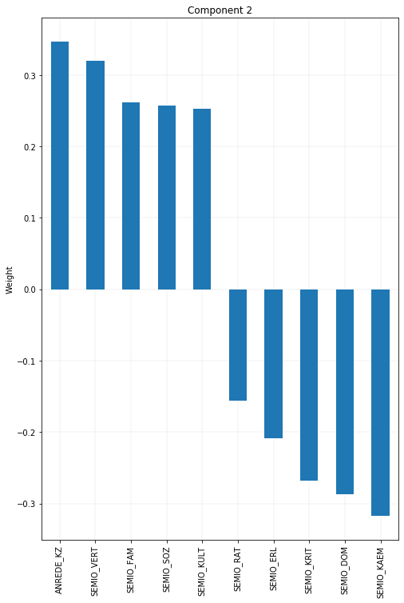

```
ANREDE_KZ     0.346741
SEMIO_VERT    0.320291
SEMIO_FAM     0.261977
SEMIO_SOZ     0.257613
SEMIO_KULT    0.252937
SEMIO_RAT    -0.155655
SEMIO_ERL    -0.208579
SEMIO_KRIT   -0.268303
SEMIO_DOM    -0.286512
SEMIO_KAEM   -0.317349
Name: 2, dtype: float64
```

```python
# Map weights for the third principal component to corresponding feature names
# and then print the linked values, sorted by weight.

component_weight = plot_comp_weight(clean_under_30_pca, pca, 2, 5)
component_weight
```

### Discussion: Component 2

#### Postive weights are:

ANREDE_KZ 0.346626 - Gender

SEMIO_VERT 0.320202 - Personality type 'dreamful'

SEMIO_FAM 0.261859 - Personality type 'family-minded'

SEMIO_SOZ 0.257582 - Personality type 'socially minded'

SEMIO_KULT 0.252820 - Personality type 'cultural minded'

#### Negative weights are:

SEMIO_RAT -0.155662 - Personality type 'rational'

SEMIO_ERL -0.208460 - Personality type 'event orientated'

SEMIO_KRIT -0.268300 - Personality type 'critical minded'

SEMIO_DOM -0.286350 - Personality type 'dominant minded'

SEMIO_KAEM -0.317150 - Personality type 'combative attitude'

It looks like component 2 is concerned with personality type and gender

## Step 3: Clustering

### Step 3.1: Apply Clustering to General Population

I assessed and cleaned the demographics data, then scaled and transformed it. Now, it's time to see how the data clusters in the principal components space.

In this substep, I will apply k-means clustering to the dataset and use the average within-cluster distances from each point to their assigned cluster's centroid to decide on a number of clusters to keep.

I will do the following steps:

- Use sklearn's KMeans class to perform k-means clustering on the PCA-transformed data.
- Then, compute the average difference from each point to its assigned cluster's center.
- Perform the above two steps for a number of different cluster counts. I will then see how the average distance decreases with an increasing number of clusters. However, each additional cluster provides a smaller net benefit. I will use this fact to select a final number of clusters in which to group the data.
- Once I've selected a final number of clusters to use, I will re-fit a KMeans instance to perform the clustering operation, taking care to obtain the cluster assignments for the general demographics data, since I'll be using them in the final Step 3.3.

```python
# Over a number of different cluster counts...

clusters = [2, 4, 6, 8, 10, 12, 14, 16, 18, 20]
scores = []

# run k-means clustering on the data and...

for cluster in clusters:
    kmeans = KMeans(n_clusters = cluster)
    model = kmeans.fit(clean_under_30_pca)

# compute the average within-cluster distances.

    score = np.abs(model.score(clean_under_30_pca))
    scores.append(score)
```

I will investigate the change in within-cluster distance across number of clusters, using matplotlib's plot function to visualise this relationship.

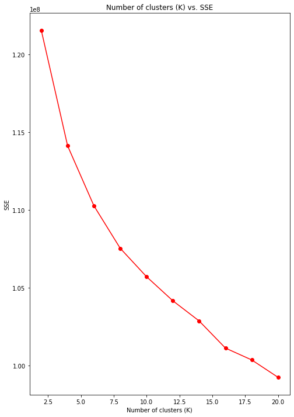

```python
plt.plot(clusters, scores, marker='o', color='r');
plt.xlabel('Number of clusters (K)')
plt.ylabel('SSE')
plt.title("Number of clusters (K) vs. SSE");
```

Although it's not very distinct from the graph, it looks like there is a slight change in angle of the line around 13 clusters (the elbow), therefore I will go ahead and fit the model to 13.

Next I re-fit the k-means model with the selected number of clusters and obtain cluster predictions for the general population demographics data.

```python
# Re-fit kmeans model with selected number of cluster
kmeans = KMeans(n_clusters=13)
model = kmeans.fit(clean_under_30_pca)
# obtain cluster predictions
predictions_general_data = model.predict(clean_under_30_pca)
```

```python
pd.DataFrame(clean_under_30_pca).to_csv("clean_under_30_pca.csv",index=False)
```

I fit our PCA-transformed general population data for a range of n-centroids 2 and 20. The score is the distance between datapoints and their corresponding centroid. The more centroids in the range, the more the score (distance between data points) will decrease. I looked for an inflection/elbow point on the graph. There isn't a strong inflection, but then agle of the line seems to change around 13-14, hence I chose 13 clusters to move forward with in my investigation.

### Step 3.2: Apply All Steps to the Customer Data

Now that I have clusters and cluster centers for the general population, let's see how the customer data maps on to those clusters.

This does not mean re-fitting all of the models to the customer data. Instead, I am using the fits from the general population to clean, transform, and cluster the customer data.

Then, I will interpret how the general population fits apply to the customer data.

- I apply the same feature wrangling, selection, and engineering steps to the customer demographics using the `clean_data()` function created earlier. (I've been told that I can assume that the customer demographics data has similar meaning behind missing data patterns as the general demographics data.)
- I will use the sklearn objects from the general demographics data, and apply their transformations to the customers data. I will not be using a `.fit()` or `.fit_transform()` method to re-fit the old objects, nor will I create new sklearn objects. I will carry the data through the feature scaling, PCA, and clustering steps, obtaining cluster assignments for all of the data in the customer demographics data.

```python
# Load in the customer demographics data.
customers = pd.read_csv('Udacity_CUSTOMERS_Subset.csv', delimiter=';')
```

```python
# Apply preprocessing done on the general demographics onto the customer data by calling the earlier define'clean_data' function

customers_cleaned = clean_data(customers)
```

```python
#check that the column names are the same between the two datasets

customers_cleaned.columns

for columnsnames in under_30_columns:
    if columnsnames not in customers_cleaned.columns:
        print(columnsnames)
```

```python
customers_cleaned.columns

for columnsnames in customers_cleaned.columns:
    if columnsnames not in under_30_columns:
        print(columnsnames)
```

```python
customers_cleaned.head()
```

|  | ALTERSKATEGORIE_GROB | ANREDE_KZ | FINANZ_MINIMALIST | FINANZ_SPARER | FINANZ_VORSORGER | FINANZ_ANLEGER | FINANZ_UNAUFFAELLIGER | FINANZ_HAUSBAUER | GREEN_AVANTGARDE | HEALTH_TYP | RETOURTYP_BK_S | SEMIO_SOZ | SEMIO_FAM | SEMIO_REL | SEMIO_MAT | SEMIO_VERT | SEMIO_LUST | SEMIO_ERL | SEMIO_KULT | SEMIO_RAT | SEMIO_KRIT | SEMIO_DOM | SEMIO_KAEM | SEMIO_PFLICHT | SEMIO_TRADV | SOHO_KZ | VERS_TYP | ANZ_PERSONEN | ANZ_TITEL | … |
| --- | --- | --- | --- | --- | --- | --- | --- | --- | --- | --- | --- | --- | --- | --- | --- | --- | --- | --- | --- | --- | --- | --- | --- | --- | --- | --- | --- | --- | --- | --- |
| 0 | 4.0 | 1 | 5 | 1 | 5 | 1 | 2 | 2 | 1 | 1.0 | 5.0 | 6 | 5 | 2 | 6 | 6 | 7 | 3 | 4 | 1 | 3 | 1 | 1 | 2 | 1 | 0.0 | 1.0 | 2.0 | 0.0 | … |
| 2 | 4.0 | 0 | 5 | 1 | 5 | 1 | 4 | 4 | 1 | 2.0 | 5.0 | 2 | 2 | 1 | 3 | 3 | 7 | 7 | 1 | 2 | 7 | 5 | 6 | 4 | 1 | 0.0 | 0.0 | 1.0 | 0.0 | … |
| 3 | 4.0 | 1 | 5 | 1 | 5 | 2 | 1 | 2 | 0 | 2.0 | 3.0 | 6 | 5 | 3 | 4 | 7 | 5 | 3 | 4 | 3 | 3 | 3 | 3 | 3 | 4 | 0.0 | 1.0 | 0.0 | 0.0 | … |
| 4 | 3.0 | 1 | 3 | 1 | 4 | 4 | 5 | 2 | 0 | 3.0 | 5.0 | 4 | 5 | 4 | 6 | 5 | 6 | 4 | 5 | 5 | 3 | 5 | 2 | 5 | 4 | 0.0 | 0.0 | 4.0 | 0.0 | … |
| 5 | 3.0 | 1 | 5 | 1 | 5 | 1 | 2 | 3 | 1 | 3.0 | 3.0 | 6 | 4 | 4 | 1 | 7 | 6 | 4 | 6 | 2 | 5 | 5 | 3 | 3 | 4 | 0.0 | 0.0 | 2.0 | 0.0 | … |

```python
#verify that the shapes are the same
customers_cleaned.shape
```

```
(141725, 192)
```

```python
under_30.shape
```

```
(798067, 192)
```

```python
#the customer data needs to be imputed as well

customers_cleaned_imp = impute_most_frequent_all.transform(customers_cleaned)
```

```python
# Apply preprocessing, feature transformation, and clustering from the general
# demographics onto the customer data, obtaining cluster predictions for the
# customer demographics data.

# scaling
customers_scaled = scaler.transform(customers_cleaned_imp)
customers_scaled = pd.DataFrame(customers_scaled, columns=customers_cleaned.columns)

# PCA transformation
customers_pca = pca.transform(customers_scaled)

# kmeans prediction
customers_kmeans = kmeans.predict(customers_pca)
```

### Step 3.3: Compare Customer Data to Demographics Data

At this point, I have clustered data based on demographics of the general population of Germany, and seen how the customer data for a mail-order sales company maps onto those demographic clusters. In this final substep, I will compare the two cluster distributions to see where the strongest customer base for the company is.

I will consider the proportion of persons in each cluster for the general population, and the proportions for the customers.

If the assumption is that the company's customer base to be universal, then the cluster assignment proportions should be fairly similar between the two.

If there are only particular segments of the population that are interested in the company's products, then I should see a mismatch from one to the other.

If there is a higher proportion of persons in a cluster for the customer data compared to the general population (e.g. 5% of persons are assigned to a cluster for the general population, but 15% of the customer data is closest to that cluster's centroid) then that suggests the people in that cluster should be a target audience for the company.

On the other hand, the proportion of the data in a cluster being larger in the general population than the customer data (e.g. only 2% of customers closest to a population centroid that captures 6% of the data) suggests that group of persons to be outside of the target demographics.

I will do the following points in this step:

- Compute the proportion of data points in each cluster for the general population and the customer data. Visualisations will be useful here: both for the individual dataset proportions, but also to visualise the ratios in cluster representation between groups.
- See which cluster or clusters are overrepresented in the customer dataset compared to the general population, select at least one such cluster and infer what kind of people might be represented by that cluster. Use the principal component interpretations from step 2.3 or look at additional components to help make this inference. (Alternatively, I could've use the `.inverse_transform()` method of the PCA and StandardScaler objects to transform centroids back to the original data space and interpret the retrieved values directly.)
- Perform a similar investigation for the underrepresented clusters to see which cluster or clusters are underrepresented in the customer dataset compared to the general population, and what kinds of people are typified by these clusters.

```python
#Turn the results of the kmeans to a dataframe rather than a numpy array

final_gdd_data = pd.DataFrame(predictions_general_data, columns=['final_gdd'])
final_cust_data = pd.DataFrame(customers_kmeans, columns=['final_cust'])
```

```python
#Create the proportions of the total that each cluster in each dataset represents, to compare them

proportion_gdd = final_gdd_data['final_gdd'].value_counts().sort_index()/ \
                sum(final_gdd_data['final_gdd'].value_counts())
proportion_cust = final_cust_data['final_cust'].value_counts().sort_index()/ \
                sum(final_cust_data['final_cust'].value_counts())
```

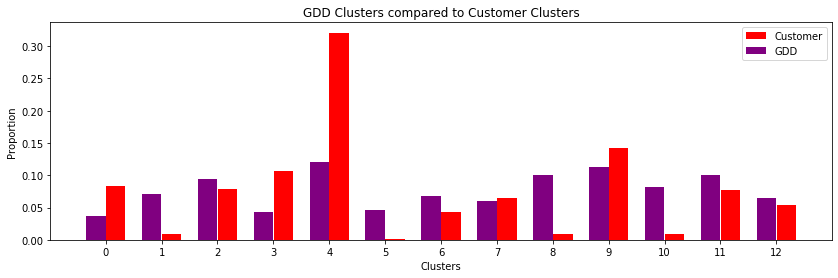

```python
fig,ax = plt.subplots(figsize=(14,4))
width = 0.35

gdd = ax.bar(proportion_gdd.index+.51*width, proportion_cust, width, color='red')
cust = ax.bar(proportion_cust.index-.51*width, proportion_gdd, width, color='purple')


ax.set_ylabel('Proportion')
ax.set_xlabel('Clusters')
ax.set_title('GDD Clusters compared to Customer Clusters')
ax.set_xticks(proportion_cust.index)
ax.legend(('Customer','GDD'))
```

```python
#Use the 'component_weight' function written earlier when introducing pca

cluster = model.cluster_centers_[7]
cluster_df = pd.DataFrame(cluster,columns=['component_weight'])
cluster_7_sort = cluster_df.sort_values(by='component_weight',ascending=False)
cluster_7 = pd.concat([cluster_7_sort.head(), cluster_7_sort.tail()])
cluster_7
```

|  | component_weight |
| --- | --- |
| 1 | 2.676385 |
| 7 | 1.966923 |
| 2 | 1.274891 |
| 3 | 1.143303 |
| 0 | 0.646283 |
| 14 | -0.890654 |
| 9 | -0.903879 |
| 12 | -1.159600 |
| 4 | -1.361617 |
| 5 | -1.552554 |

I can see the components and their weighting sorted by values.

Showing the first and last 5 shows me the components the furthest away from 0 for cluster 7.

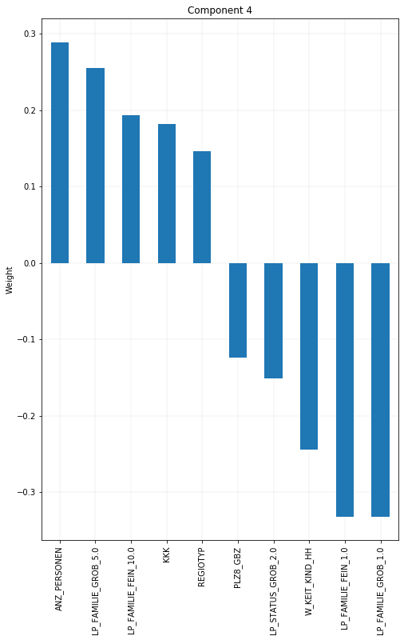

```
ANZ_PERSONEN            0.289058
LP_FAMILIE_GROB_5.0     0.255552
LP_FAMILIE_FEIN_10.0    0.193605
KKK                     0.182078
REGIOTYP                0.145953
PLZ8_GBZ               -0.124276
LP_STATUS_GROB_2.0     -0.150994
W_KEIT_KIND_HH         -0.244168
LP_FAMILIE_FEIN_1.0    -0.332012
LP_FAMILIE_GROB_1.0    -0.332012
Name: 4, dtype: float64
```

```python
component_weight = plot_comp_weight(clean_under_30_pca, pca, 4, 5)
component_weight
```

ANZ_PERSONEN - number of adults in the household

LP_FAMILIE_FEIN_10.0 - two generational household

LP_FAMILIE_GROB_5.0 - multi person household

KKK - purchasing power in the region

REGIOTYP - Neighbourhood typology

PLZ8_GBZ - Number of buildings within the PLZ8 region

LP_STATUS_GROB_2.0 - average earners

W_KEIT_KIND_HH - Likelihood of children in household

LP_FAMILIE_FEIN_1.0 - single

LP_FAMILIE_GROB_1.0 - single

Component 4 is most positively explained by multiple people in the household and most negatively explained by single people.

```python
component_weight = plot_comp_weight(clean_under_30_pca, pca, 0, 5)
component_weight
```

```
LP_STATUS_GROB_1.0        0.197467
HH_EINKOMMEN_SCORE        0.186070
CAMEO_INTL_2015_WEALTH    0.185030
PLZ8_ANTG3                0.182028
PLZ8_ANTG4                0.175643
KBA05_ANTG1              -0.180883
KBA05_GBZ                -0.181540
PLZ8_ANTG1               -0.183152
MOBI_REGIO               -0.188299
FINANZ_MINIMALIST        -0.195395
Name: 0, dtype: float64
```

LP_STATUS_GROB_1.0 - low-income earners

HH_EINKOMMEN_SCORE - Estimated household net income

CAMEO_INTL_2015_WEALTH - Level of wealth

PLZ8_ANTG3 - Number of 6-10 family houses in the PLZ8 region

PLZ8_ANTG4 - Number of 10+ family houses in the PLZ8 region

KBA05_ANTG1 - Number of 1-2 family houses in the microcell

KBA05_GBZ - Number of buildings in the microcell

PLZ8_ANTG1 - Number of 1-2 family houses in the PLZ8 region

MOBI_REGIO - Movement patterns

FINANZ_MINIMALIST - low financial interest

Component 0 is most positively explained by low income earners in neighbourhoods with high capacity houses and negatively explained by neighbourhoods with low capacity houses and movement patterns.

What kinds of people are part of a cluster **(8)** that is under represented in the customer data compared to the general population?

```python
cluster = model.cluster_centers_[8]
cluster_df = pd.DataFrame(cluster,columns=['component_weight'])
cluster_8_sort = cluster_df.sort_values(by='component_weight',ascending=False)
cluster_8 = pd.concat([cluster_8_sort.head(), cluster_8_sort.tail()])
cluster_8
```

|  | component_weight |
| --- | --- |
| 0 | 4.002413 |
| 12 | 0.721378 |
| 3 | 0.540645 |
| 20 | 0.360563 |
| 23 | 0.296619 |
| 16 | -0.603438 |
| 10 | -0.641323 |
| 21 | -0.673999 |
| 1 | -2.217448 |
| 2 | -2.606972 |

```python
component_weight = plot_comp_weight(clean_under_30_pca, pca, 0, 5)
component_weight
```

```
LP_STATUS_GROB_1.0        0.197467
HH_EINKOMMEN_SCORE        0.186070
CAMEO_INTL_2015_WEALTH    0.185030
PLZ8_ANTG3                0.182028
PLZ8_ANTG4                0.175643
KBA05_ANTG1              -0.180883
KBA05_GBZ                -0.181540
PLZ8_ANTG1               -0.183152
MOBI_REGIO               -0.188299
FINANZ_MINIMALIST        -0.195395
Name: 0, dtype: float64
```

### Results - Component 0 (positively weighted by cluster 8)

The same features apply to component 0 here as discussed in the above cells.

Cluster 8 is under represented in the customer data. Component 0 has the greatest positive weighting concerning cluster 8.

Component 0 is most positively explained by low income earners in neighbourhoods with high capacity houses and negatively explained by neighbourhoods with low capacity houses and movement patterns.

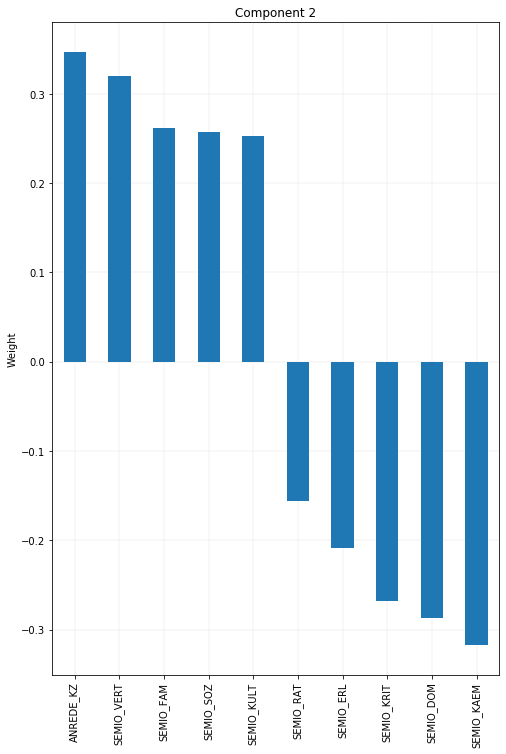

```
ANREDE_KZ     0.346741
SEMIO_VERT    0.320291
SEMIO_FAM     0.261977
SEMIO_SOZ     0.257613
SEMIO_KULT    0.252937
SEMIO_RAT    -0.155655
SEMIO_ERL    -0.208579
SEMIO_KRIT   -0.268303
SEMIO_DOM    -0.286512
SEMIO_KAEM   -0.317349
Name: 2, dtype: float64
```

```python
component_weight = plot_comp_weight(clean_under_30_pca, pca, 2, 5)
component_weight
```

### Results - Component 2 (negatively weighted by cluster 8)

ANREDE_KZ - Gender

SEMIO_VERT - Dreamful personality

SEMIO_FAM - Family minded personality

SEMIO_SOZ - Socially minded personality

SEMIO_KULT - Culturally minded personality

SEMIO_RAT - Rational personality

SEMIO_ERL - Event orientated personality

SEMIO_KRIT - Critical minded personality

SEMIO_DOM - Dominant minded personality

SEMIO_KAEM - Combative personality

Component 2 is positively explained by dramful and family minded personality types and negatively explained by rational and critical minded personality types.

### Discussion 3.3: Compare Customer Data to Demographics Data

#### Conclusion

Those not interested in finance and low income earners being part of the most under represented cluster makes sense, as it would be avisable for the company not to target people with these characteristics.

#### Limitations and opportunities for improvement

I encountered a problem at the customer cleaning stage when I applied the onehotencoder then was missing a column in the customer dataset, because '5' didn't appear as a response of GEBAEUDETYP in the customer data. I applied a workaround by creating a column and filling it with 0, however, to avoid this in future it could be improved by using a different type of encoder like leave one out coding or conditional probability encoding or target encoding.

(source: https://stackoverflow.com/questions/47460387/how-do-i-resolve-one-hot-encoding-if-my-test-data-has-missing-values-in-a-col)

During the initial cleaning stages we dropped all rows with more than 30 missing values. We cold have imputed these values to see if their presence has an effect on the results.